# Windows下R与Rstudio的安装

王宁宁

下面是R以及相关的组件的安装：（注意图片的版本没有及时更新）

**注意：如果你是首次安装，强烈建议先安装R，然后安装Rstudio。**

## R的安装

- 访问 http://cran.r-project.org/
- 点击 `Download R for Windows`

[figure not shown]

- 点击 `base`

[figure not shown]

- 点击 `Download R 3.x.x for Windows`

[figure not shown]

- 打开并运行下载的 `R-3.x.x-win.exe`
- 所有选择可以选择默认方式

.

.

.

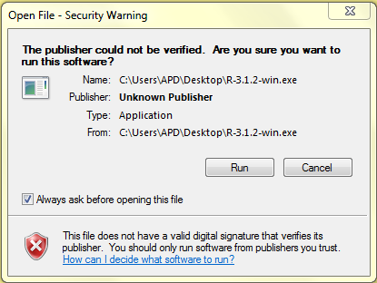

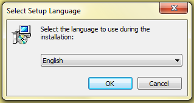

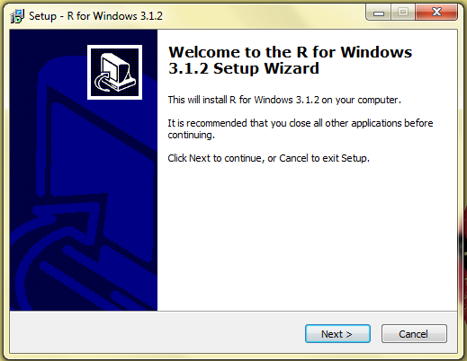

**1**

**2**

**3**

[figure not shown]

[figure not shown]

[figure not shown]

**4**

**5**

**6**

[figure not shown]

[figure not shown]

[figure not shown]

**7**

**8**

**9**

[figure not shown]

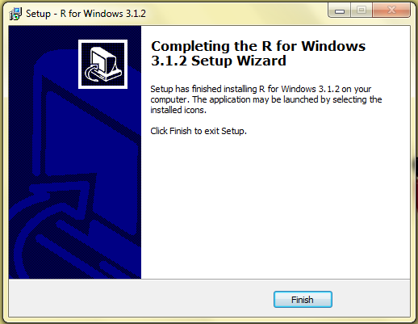

**DONE**

**10**

**11**

- 安装最新的版本 (R version 3.x.x)。

## 安装 Rtools（可选）

**在前面的学习中可以不用安装这一组件**

- 下面安装 Rtools
- 访问 http://cran.r-project.org/
- 点击 `Download R for Windows`

[figure not shown]

- 点击 `Rtools`

[figure not shown]

- 下载 `Rtools3x.exe` （此处注意要选择与安装的版本一致）

[figure not shown]

- Open and run the file you just downloaded `Rtools3x.exe`
- 同样没有必要更改选项

.

.

.

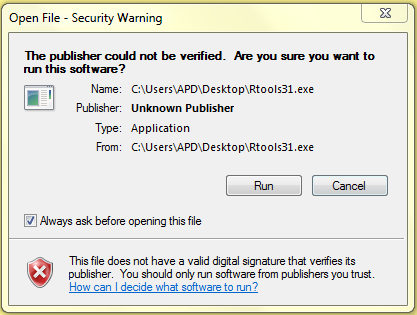

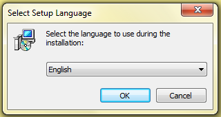

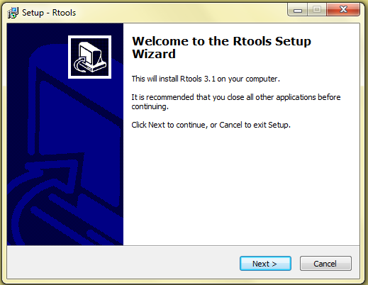

**1**

**2**

**3**

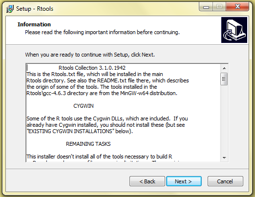

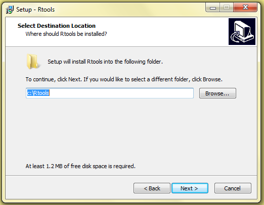

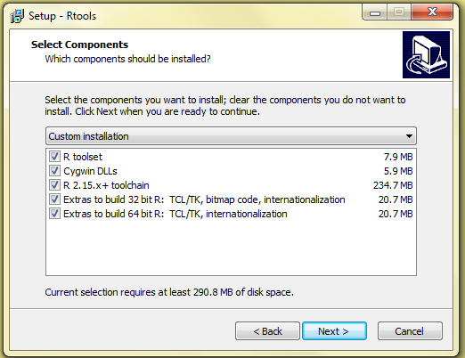

**4**

**5**

**6**

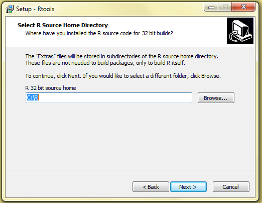

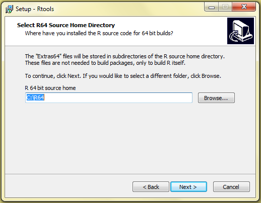

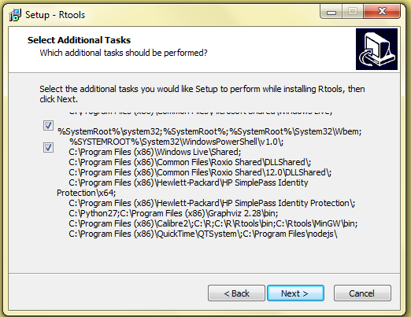

**7**

**8**

**9**

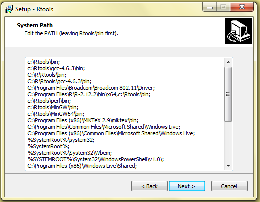

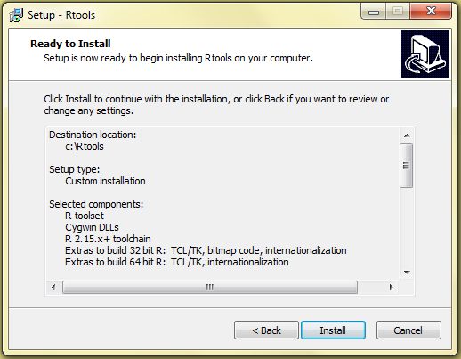

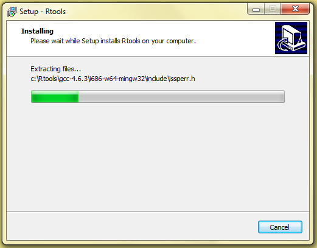

**10**

**11**

**12**

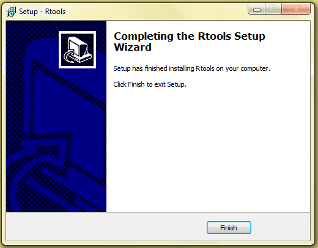

**DONE**

**13**

**14**